# Análisis Estadístico del Conocimiento, Uso y Percepción de la Criptomoneda Pi Network entre Estudiantes Universitarios

Authors

Alvaro Lira

Giacomo Bacigalupo Dobaño

Eliseo Cervantes Ordóñez

Santiago Loayza Rivera

Jorge Cruz

Published

May 28, 2025

# 1 Introducción

## 1.1 Relevancia

El estudio del conocimiento, uso y percepción de la criptomoneda Pi Network entre estudiantes universitarios es relevante debido al creciente interés en las nuevas tecnologías financieras descentralizadas. Los jóvenes, especialmente los estudiantes universitarios, representan un grupo demográfico clave para la adopción temprana de innovaciones digitales como las criptomonedas. Comprender su nivel de conocimiento, frecuencia de uso y percepciones frente a las criptomonedas como Pi Network permite identificar barreras de adopción, oportunidades educativas y posibles tendencias en la economía digital.

## 1.2 Planificación

La planificación del trabajo incluye un conjunto de tareas organizadas de manera sensata y coherente, permitiendo cumplir con los objetivos del proyecto dentro de los plazos establecidos. Cada tarea específica ha sido asignada a un miembro del grupo, indicando el tiempo estimado para su finalización.

El trabajo completo del proyecto se ha dividido en las siguientes fases:

1. **Definición del problema y objetivos**: Identificar y establecer los objetivos del estudio.

2. **Recolección de datos**: Diseñar y distribuir el cuestionario, así como recopilar las respuestas.

3. **Limpieza y procesamiento de datos**: Preparar los datos para su análisis eliminando errores y completando valores faltantes.

4. **Análisis estadístico**: Realizar análisis descriptivos y bivariados utilizando herramientas estadísticas.

5. **Interpretación de resultados y conclusiones**: Derivar conclusiones basadas en los hallazgos.

6. **Elaboración del informe final**: Redactar el informe y presentar los resultados.

El siguiente diagrama de Gantt ilustra la planificación detallada, asignando tareas específicas a los integrantes del grupo y definiendo los tiempos esperados para cada actividad.

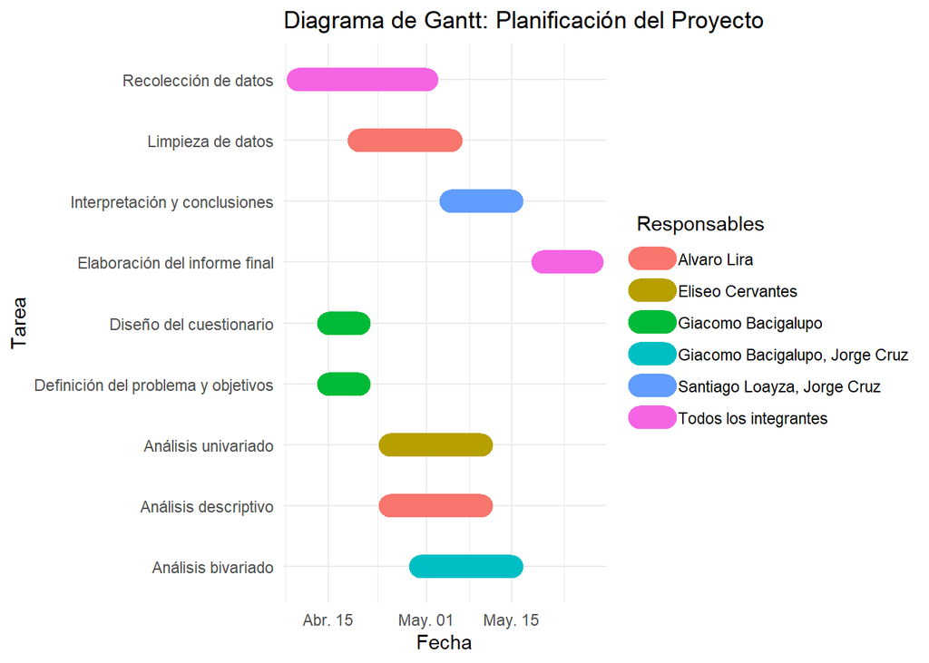

## 1.3 Contexto

Pi Network es una plataforma de criptomoneda centrada en la minería móvil, desarrollada por Nicolas Kokkalis, Chengdiao Fan y Vince McPhillip, todos ellos egresados de la Universidad de Stanford. En la actualidad, esta criptomoneda ocupa el puesto número 26 entre las criptomonedas activas listadas en CoinMarketCap según su capitalización de mercado.El principal objetivo de Pi Network es formar una comunidad global de “pioneros” que participen activamente en el fortalecimiento de la red y en el desarrollo continuo de la plataforma.

## 1.4 Objetivo General

Analizar mediante herramientas estadísticas el comportamiento, percepción, conocimiento y adopción de la criptomoneda Pi Network en estudiantes universitarios, integrando variables cualitativas y cuantitativas que permitan aplicar distribuciones de probabilidad, pruebas de hipótesis y análisis de regresión.

## 1.5 Objetivos Específicos

- Estimar el porcentaje de estudiantes que han minado Pi Network, otras criptomonedas gratuitas y de pago ,segmentándolos por su tipo de carrera ,departamento de procedencia y nivel de educación financiera .
- Analizar el promedio de gasto mensual desde la billetera digital (Yape, Plin u otro) y efectivo de los estudiantes universitarios comparándolo con su adopción por las criptomonedas, y segmentando los resultados por su escala socioeconómica.

# 2 Datos

## 2.1 Población objetivo

Población de estudio: estudiantes de la Universidad de Ingeniería y Tecnología (UTEC).

Unidades muestrales: estudiantes individuales de UTEC que respondieron voluntariamente al cuestionario distribuido a través de Google Forms. Cada respuesta representa una unidad de análisis para el estudio.

## 2.2 Tipo de muestreo

El tipo de muestreo utilizado es muestreo no probabilístico por conveniencia. Esto significa que los estudiantes fueron seleccionados principalmente por la facilidad de acceso, ya que el cuestionario fue distribuido mediante Google Forms.

## 2.3 Recolección de datos

Para el instrumento de recolección usaremos archivos csv obtenidos mediante la toma de datos hecho en un Google forms, fuente primaria de información.[Google forms](https://docs.google.com/forms/d/e/1FAIpQLSccLVP3DT-cO_3e5J91PF3yjr8FL0Ds9Sb9_XcGlcKNaAO1Fw/viewform)

## 2.4 Variables

Un resumen de las variables que escogimos para nuestro estudio.

| **Variable** | **Tipo** |
| --- | --- |
| carrera | Cualitativa nominal |
| departamento | Cualitativa nominal |
| participacion_cripto | Cualitativa nominal |
| intencion_cripto | Cualitativa nominal |
| Nivel_socieconomico | Cualitativa ordinal |
| frecuencia_uso_billeterasV | Cualitativa ordinal |
| educacion_financiera | Cualitativa ordinal |
| frecuencia_minado_dias_semana | Cuantitativa discreta |
| cant_funciones_B.Virtual | Cuantitativa discreta |
| GastoM_efectivo | Cuantitativa continua |
| GastoM_B.digital | Cuantitativa continua |

### 2.4.1 Cualitativas nominales

- **carrera**: Campo académico al que corresponde la carrera universitaria del estudiante.
- **departamento**: Departamento de nacimiento(24 departamentos y se agrego el extranjero).
- **participacion_cripto**: Indica si el estudiante ha usado hasta el momento una criptomoneda de pago, la criptomoneda Pi Network, una gratuita o no ha invertido en absoluto.
- **intencion_cripto**: Preferencia de uso o no uso de criptomonedas ante una oportunidad de inversión.

### 2.4.2 Cualitativas ordinales

- **Nivel_socieconomico**: Ingreso familiar promedio declarado y gasto mensual clasificada en una escala del A a la E.
- **frecuencia_uso_billeterasV**: Frecuencia de uso de billeteras virtuales como Yape, Plin, entre otras.
- **educacion_financiera** : Autoevaluación del nivel de conocimientos financieros en una escala del 1 al 5.

### 2.4.3 Cuantitativas discretas

- **frecuencia_minado_dias_semana** :Número entero positivo que corresponde al número de días por semana dedicado al minado en PI Network.
- **cant_funciones_B.Virtual** :Número entero positivo que indica la cantidad de funcionalidades que utiliza en aplicaciones de billeteras virtuales.

### 2.4.4 Cuantitativas continuas

- **GastoM_efectivo** :Gasto promedio mensual en efectivo(en soles con céntimos).
- **GastoM_B.digital** :Gasto promedio mensual utilizando billeteras digitales(en soles con céntimos).

## 2.5 Limpieza de datos

Procedemos a cargar la base de datos y lo asignamos a la variable `bd`.Este es la fuente original.

```r
library(readr)
library(dplyr)
library(stringr)
library(tidyr)

# Cargar la base de datos y lo asignamos a la variable bd.
bd <- read_csv("Analisis EyP.csv")
```

Un resumen de la base de datos original.

```
La base de datos original tiene  33  variables.
```

```
La base de datos original tiene  1055  unidades muestrales.
```

```
La base de datos original tiene  2  datos faltantes.
```

```
Los nombres de las variables de la base de datos original bd son los siguientes:
```

```
 [1] "."
 [2] "¿Qué grupo lo está encuestando?"
 [3] "¿A que área pertenece tu carrera universitaria?"
 [4] "¿En qué departamento del Perú naciste?"
 [5] "Selecciona tu nivel socioeconómico"
 [6] "¿Qué tan familiarizado estas con el concepto de criptomonedas?"
 [7] "¿Qué tan interesado/a estás en poseer una criptomoneda?"
 [8] "¿Cuánto conoces la criptomoneda Pi Network?"
 [9] "¿Hace cuantos meses creaste tu cuenta Pi Network, aproximadamente?"
[10] "Marca las opciones que más te representen:"
[11] "Pensando en el riesgo de pérdida, ¿Cuál es la cantidad (en soles) que aceptarías perder como parte del proceso de aprender a invertir en Pi Network?\nEjemplo de respuesta: \"100\"  \"20\"\nRespuesta indeseada: \"100 soles\" \"cien soles\""
[12] "¿Estaría dispuesto a invertir en Pi Network? Si es así, ¿cuánto?"
[13] "¿Cuál sería tu mayor preocupación respecto a Pi Network a la hora de invertir?"
[14] "¿Qué nivel de confianza tienes en la seguridad de Pi Network como criptomoneda?"
[15] "Si tuvieras que elegir entre invertir en una criptomoneda conocida (como Bitcoin) o una nueva como Pi Network, ¿Cuál preferirías?"
```

[output cut: 18 more lines]

Para nuestro estudio, seleccionamos las variables que necesitamos y eliminamos las que no proporcionan información relevante.Eliminamos la dos primeras columnas que corresponden a la Marca Temporal y el grupo que encuestó nombradas `.` y `¿Qué grupo lo está encuestando?` respectivamente.Además,seleccionamos las variables relevantes para nuestro estudio indicado en la clasificación de las variables y lo asignamos a un nuevo base de datos denominada `bdf`.En total, son 11 variables y las renombramos para una mejor comprensión.

```r
bd <- bd %>% select(-1,-2)
# Otra forma de realizarlo: bd <- bd %>% select(-.,-`¿Qué grupo lo está encuestando?`)

# Seleccionamos las variables relevantes para nuestro estudio indicado en la clasificación de las variables y lo asignamos al dataframe bdf.
bdf <- bd %>% select(1:3,8,13,15,17,24,25,27,28)

#Renombrando las variables.
bdf=bdf %>% rename(carrera=`¿A que área pertenece tu carrera universitaria?`, departamento=`¿En qué departamento del Perú naciste?`, Nivel_socieconomico=`Selecciona tu nivel socioeconómico`, participacion_cripto=`Marca las opciones que más te representen:` , intencion_cripto=`Si tuvieras que elegir entre invertir en una criptomoneda conocida (como Bitcoin) o una nueva como Pi Network, ¿Cuál preferirías?` ,frecuencia_minado_dias_semana=`¿Cuántos días a la semana le dedicas al minado de Pi Network?` , educacion_financiera=`¿Cómo calificarías tu nivel de educación financiera`, frecuencia_uso_billeterasV=`¿Con qué frecuencia realizas transacciones con billeteras digitales como Yape o Plin?`, GastoM_B.digital=`¿Cuál es tu promedio mensual de dinero gastado solo desde tu billetera digital (Yape, Plin, etc)? (Numero en Soles) Ej: 300` ,GastoM_efectivo=`¿Cuál es tu promedio mensual de dinero gastado solo en efectivo? (Numero en Soles) Ej: 300`,cant_funciones_B.Virtual=`Cuantas funciones crees que usas en las apps de billeteras digitales. (Ejemplo: 2)`)
```

```
Los nombres de las variables del dataframe bdf son los siguientes:
```

```
 [1] "carrera"                       "departamento"
 [3] "Nivel_socieconomico"           "participacion_cripto"
 [5] "intencion_cripto"              "frecuencia_minado_dias_semana"
 [7] "educacion_financiera"          "frecuencia_uso_billeterasV"
 [9] "cant_funciones_B.Virtual"      "GastoM_B.digital"
[11] "GastoM_efectivo"
```

Un resumen de la base de datos final denominada `bdf`.

```
Resumen del dataframe bdf:
```

```
tibble [1,055 × 11] (S3: tbl_df/tbl/data.frame)
 $ carrera                      : chr [1:1055] "Ingenierías" "Ingenierías" "Administrativas" "Ingenierías" ...
 $ departamento                 : chr [1:1055] "Lima" "San Martín" "Lima" "Lima" ...
 $ Nivel_socieconomico          : chr [1:1055] "Medio (NSE C)" "Bajo (NSE E)" "Medio- Alto (NSE B)" "Medio (NSE C)" ...
 $ participacion_cripto         : chr [1:1055] "No he minado o invertido" "No he minado o invertido" "No he minado o invertido" "No he minado o invertido" ...
 $ intencion_cripto             : chr [1:1055] "Dependería de la información que tenga" "Dependería de la información que tenga" "Bitcoin u otra ya establecida" "Bitcoin u otra ya establecida" ...
 $ frecuencia_minado_dias_semana: num [1:1055] 1 0 0 0 2 0 6 0 0 3 ...
 $ educacion_financiera         : num [1:1055] 2 4 1 3 3 3 3 4 4 3 ...
 $ frecuencia_uso_billeterasV   : chr [1:1055] "Una vez a la semana" "Diariamente" "Varias veces por semana" "Varias veces por semana" ...
 $ cant_funciones_B.Virtual     : chr [1:1055] "3" "4" "2" "1" ...
 $ GastoM_B.digital             : chr [1:1055] "20" "400" "30" "30" ...
 $ GastoM_efectivo              : chr [1:1055] "120" "2000" "150" "500" ...
```

```
Número de variables en el dataframe bdf:  11
```

```
Número de unidades muestrales en el dataframe bdf:  1055
```

```
Tamaño efectivo de cada variable:
```

```
                      carrera                  departamento
                         1055                          1055
          Nivel_socieconomico          participacion_cripto
                         1055                          1055
             intencion_cripto frecuencia_minado_dias_semana
                         1055                          1055
         educacion_financiera    frecuencia_uso_billeterasV
                         1055                          1055
     cant_funciones_B.Virtual              GastoM_B.digital
                         1055                          1055
              GastoM_efectivo
                         1055
```

```
La base de datos tiene  0  datos faltantes.
```

**Limpieza de la variable carrera**

El forms presento la elección de carreras de la siguiente manera:

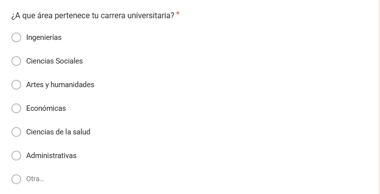

. Sin embargo,se permitió al usuario ingresar su carrera en la opción `Otros`.Para la limpieza, se ha considerado solo los 7 valores únicos que se observa en la imagen.La variable `carrera` es de tipo character según la clasificación de R. Originalmente, había 50 valores únicos.

```r
bdf <- bdf %>%
  mutate(carrera = factor(case_when(
    carrera %in% c("Ingenierías",
                   "Ciencias Sociales",
                   "Artes y humanidades",
                   "Económicas",
                   "Ciencias de la salud",
                   "Administrativas") ~ carrera,
    TRUE ~ "Otra"
  ), levels = c("Ingenierías",
                "Ciencias Sociales",
                "Artes y humanidades",
                "Económicas",
                "Ciencias de la salud",
                "Administrativas",
                "Otra")))

carreras <- bdf %>%
  group_by(carrera) %>%
  summarize(n = n())

carreras
```

```
# A tibble: 7 × 2
  carrera                  n
  <fct>                <int>
1 Ingenierías            631
2 Ciencias Sociales       63
3 Artes y humanidades     58
4 Económicas              61
5 Ciencias de la salud   100
6 Administrativas         70
7 Otra                    72
```

**Limpieza de la variable departamento**

La variable `departamento` proviene de una pregunta de solo una opción para elegir entre los 24 valores únicos por lo que esta limpia.Según la clasificación de R,esta variable es de tipo character .

```
     Amazonas        Áncash      Apurímac      Arequipa      Ayacucho
            2            10             7            24            13
    Cajamarca         Cusco    Extranjero  Huancavelica       Huánuco
           25            32            31            11            11
          Ica         Junín   La Libertad    Lambayeque          Lima
           29            39            31            62           667
       Loreto Madre de Dios         Pasco         Piura          Puno
            2             2             2            27             8
   San Martín         Tacna        Tumbes       Ucayali
            7             4             5             4
```

```
Según la base de datos, no hay personas que nacieron en Moquegua.
```

**Limpieza de la variable Nivel_socieconomico**

La variable `Nivel_socieconomico` proviene de una pregunta de solo una opción para elegir entre los 5 valores únicos por lo que esta limpia.Según la clasificación de R,esta variable es de tipo character.Como es una variable cualitativa ordinal,se procede a usar la función `factor`.

```r
table(bdf$Nivel_socieconomico)
```

```
        Alto (NSE A)         Bajo (NSE E)  Medio- Alto (NSE B)
                 152                   97                  321
Medio - Bajo (NSE D)        Medio (NSE C)
                 183                  302
```

```r
#Aqui notamos que hay 5 datos unicos
bdf$Nivel_socieconomico=factor(bdf$Nivel_socieconomico,levels = c("Bajo (NSE E)","Medio - Bajo (NSE D)","Medio (NSE C)","Medio- Alto (NSE B)","Alto (NSE A)"),ordered = TRUE)

unique(bdf$Nivel_socieconomico)
```

```
[1] Medio (NSE C)        Bajo (NSE E)         Medio- Alto (NSE B)
[4] Alto (NSE A)         Medio - Bajo (NSE D)
5 Levels: Bajo (NSE E) < Medio - Bajo (NSE D) < ... < Alto (NSE A)
```

**Limpieza de la variable participacion_cripto**

El forms presentó una pregunta de opciones múltiples para la variable `participacion_cripto` de la siguiente manera:

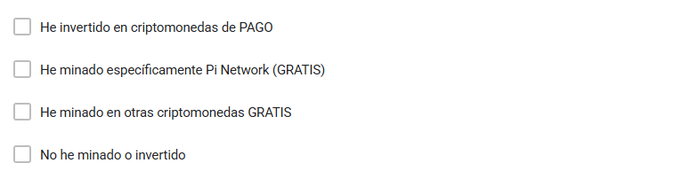

.La variable `participacion_cripto` es de tipo character.

```
Los valores unicos antes de la limpieza de la variable:
```

```
 [1] "No he minado o invertido"
 [2] "He minado en otras criptomonedas GRATIS"
 [3] "He minado específicamente Pi Network (GRATIS)"
 [4] "He invertido en criptomonedas de PAGO"
 [5] "He invertido en criptomonedas de PAGO, He minado específicamente Pi Network (GRATIS), He minado en otras criptomonedas GRATIS"
 [6] "He invertido en criptomonedas de PAGO, He minado en otras criptomonedas GRATIS"
 [7] "He minado específicamente Pi Network (GRATIS), He minado en otras criptomonedas GRATIS"
 [8] "He invertido en criptomonedas de PAGO, He minado específicamente Pi Network (GRATIS)"
 [9] "He invertido en criptomonedas de PAGO, He minado específicamente Pi Network (GRATIS), He minado en otras criptomonedas GRATIS, No he minado o invertido"
[10] "He minado en otras criptomonedas GRATIS, No he minado o invertido"
[11] "He invertido en criptomonedas de PAGO, No he minado o invertido"
[12] "He minado específicamente Pi Network (GRATIS), He minado en otras criptomonedas GRATIS, No he minado o invertido"
[13] "He minado específicamente Pi Network (GRATIS), No he minado o invertido"
```

```
Hay  13  valores únicos(algunos con más de una opción)
```

Se procede a separar las opciones en 4 columnas mas añadidas al dataframe para contabilizar la frecuencia de cada una.

```r
#data <- bdf %>%separate(participacion_cripto, into = c("opcion1", "opcion2", "opcion3","opcion4"), sep = ",")
#hay cadenas invisibles

bdf <- bdf %>%
  mutate(
    opcion1 = if_else(str_detect(participacion_cripto, fixed("No he minado o invertido")), TRUE, FALSE),
    opcion2 = if_else(str_detect(participacion_cripto, fixed("He minado en otras criptomonedas GRATIS")), TRUE, FALSE),
    opcion3 = if_else(str_detect(participacion_cripto, fixed("He minado específicamente Pi Network (GRATIS)")), TRUE, FALSE),
    opcion4 = if_else(str_detect(participacion_cripto, fixed("He invertido en criptomonedas de PAGO")), TRUE, FALSE )
  )
opciones_seleccionadas <- colSums(bdf[, 12:15])
opciones_seleccionadas
```

```
opcion1 opcion2 opcion3 opcion4
    719     177     169     134
```

**Limpieza de la variable intencion_cripto**

La variable `intencion_cripto` proviene de una pregunta de solo una opción para elegir entre los 4 valores únicos por lo que esta limpia.Según la clasificación de R,esta variable es de tipo character .

```
         Bitcoin u otra ya establecida Dependería de la información que tenga
                                   338                                    388
                               Ninguna                             Pi Network
                                   189                                    140
```

**Limpieza de la variable frecuencia_minado_dias_semana**

La variable `frecuencia_minado_dias_semana` proviene de una pregunta de solo una opción para elegir entre los 8 valores únicos.Según la clasificación de R,esta variable es de tipo numeric.

```
  0   1   2   3   4   5   6   7
705  57  65  80  52  49  21  26
```

**Limpieza de la variable educacion_financiera**

La variable `educacion_financiera` proviene de una pregunta de solo una opción para elegir entre los 5 valores únicos por lo que esta limpia.Según la clasificación de R,esta variable es de tipo numeric.Como es una variable cualitativa ordinal según su definición,se procede a usar las funciones `as.character` y `factor`.

```r
bdf$educacion_financiera=as.character(bdf$educacion_financiera)
table(bdf$educacion_financiera)
```

```
  1   2   3   4   5
 72 204 488 223  68
```

```r
bdf$educacion_financiera=factor(bdf$educacion_financiera,levels = c(1,2,3,4,5),ordered = TRUE)
unique(bdf$educacion_financiera)
```

```
[1] 2 4 1 3 5
Levels: 1 < 2 < 3 < 4 < 5
```

**Limpieza de la variable frecuencia_uso_billeterasV**

La variable `frecuencia_uso_billeterasV` proviene de una pregunta de solo una opción para elegir entre los 5 valores únicos por lo que esta limpia.Según la clasificación de R,esta variable es de tipo character.Como es una variable cualitativa ordinal se procede a usar la función `factor`.

```r
table(bdf$frecuencia_uso_billeterasV)
```

```
                 Diariamente Menos de una vez a la semana
                         540                           64
                       Nunca          Una vez a la semana
                          75                           94
     Varias veces por semana
                         282
```

```r
bdf$frecuencia_uso_billeterasV=factor(bdf$frecuencia_uso_billeterasV,levels=c("Nunca","Menos de una vez a la semana","Una vez a la semana","Varias veces por semana","Diariamente"),ordered = TRUE )
unique(bdf$frecuencia_uso_billeterasV)
```

```
[1] Una vez a la semana          Diariamente
[3] Varias veces por semana      Menos de una vez a la semana
[5] Nunca
5 Levels: Nunca < Menos de una vez a la semana < ... < Diariamente
```

**Limpieza de la variable cant_funciones_B.Virtual**

La variable `cant_funciones_B.Virtual` proviene de una pregunta donde se solicita al encuestado ingresar una cantidad.Según la clasificación de R,esta variable es de tipo character ya que algunos encuestados ingresaron cadenas de texto en vez de números.Además,esta variable tiene originalmente 60 valores únicos.Para la limpieza,se usa la función `as.numeric`.Esto ocasiona la inserción de NA’s.Además,consideramos que la cantidad de servicios que ofrecen las apps son enteros menores o iguales a 17.

```r
unique(bdf$cant_funciones_B.Virtual)
```

```
 [1] "3"
 [2] "4"
 [3] "2"
 [4] "1"
 [5] "8"
 [6] "5"
 [7] "0"
 [8] "5 o más"
 [9] "6"
[10] "Pago y reserva de dinero"
[11] "7"
[12] "no se"
[13] "uso yape asi que seria una"
[14] "“3”"
[15] "Pagó"
```

[output cut: 45 more lines]

```r
bdf$cant_funciones_B.Virtual=as.numeric(bdf$cant_funciones_B.Virtual)
table(bdf$cant_funciones_B.Virtual,useNA = "always")
```

```
   0    1    2    3    4    5    6    7    8   10   11   12   34   43   50  200
  42  133  385  276   91   48   13    8    3    3    1    1    1    1    1    1
 823 <NA>
   1   46
```

```r
bdf$cant_funciones_B.Virtual[bdf$cant_funciones_B.Virtual>17] <- NA
table(bdf$cant_funciones_B.Virtual,useNA = "always")
```

```
   0    1    2    3    4    5    6    7    8   10   11   12 <NA>
  42  133  385  276   91   48   13    8    3    3    1    1   51
```

**Limpieza de la variable GastoM_B.digital**

La variable `GastoM_B.digital` proviene de una pregunta donde se solicita al encuestado ingresar una cantidad.Según la clasificación de R,esta variable es de tipo character ya que algunos encuestados ingresaron cadenas de texto en vez de números.Además,esta variable tiene originalmente 129 valores únicos.Para la limpieza,se usa la función `as.numeric`.Esto ocasiona la inserción de NA’s.

```r
bdf$GastoM_B.digital=as.numeric(bdf$GastoM_B.digital)
sort(unique(bdf$GastoM_B.digital),decreasing = T)
```

```
 [1] 50000 20000  7000  5809  5000  4760  4300  4000  3500  3000  2500  2200
[13]  2030  2000  1900  1600  1500  1400  1300  1260  1200  1100  1000   920
[25]   900   870   850   800   700   654   650   620   600   575   570   550
[37]   540   525   520   500   480   460   456   450   409   400   399   380
[49]   370   360   350   345   340   320   315   310   300   280   270   250
[61]   230   220   210   200   190   180   170   160   150   140   130   129
[73]   120   100    90    80    75    70    60    50    45    40    35    30
[85]    25    20    15    12    10     5     4     3     2     1     0
```

**Limpieza de la variable GastoM_efectivo**

La variable `GastoM_efectivo` proviene de una pregunta donde se solicita al encuestado ingresar una cantidad.Según la clasificación de R,esta variable es de tipo character ya que algunos encuestados ingresaron cadenas de texto en vez de números.Además,esta variable tiene originalmente 112 valores únicos.Para la limpieza,se usa la función `as.numeric`.Esto ocasiona la inserción de NA’s.

```r
bdf$GastoM_efectivo=as.numeric(bdf$GastoM_efectivo)
sort(unique(bdf$GastoM_efectivo),decreasing = T)
```

```
 [1] 10000  5000  4000  3500  3000  2500  2450  2100  2000  1800  1560  1500
[13]  1400  1200  1130  1100  1000   900   800   790   783   780   700   600
[25]   570   500   460   458   450   430   420   400   350   348   347   345
[37]   320   300   280   270   260   257   250   240   234   230   220   210
[49]   200   195   180   160   150   140   130   126   125   120   109   100
[61]    95    90    88    80    70    64    60    55    50    45    44    40
[73]    35    30    25    20    15    12    10     5     2     1     0
```

Al finalizar la limpieza de las variables,los tamaños efectivos de las variables se han modificado.

```r
colSums(!is.na(bdf %>% select(1:11)))
```

```
                      carrera                  departamento
                         1055                          1055
          Nivel_socieconomico          participacion_cripto
                         1055                          1055
             intencion_cripto frecuencia_minado_dias_semana
                         1055                          1055
         educacion_financiera    frecuencia_uso_billeterasV
                         1055                          1055
     cant_funciones_B.Virtual              GastoM_B.digital
                         1004                          1021
              GastoM_efectivo
                         1024
```

```r
cat("La base de datos tiene ", sum(is.na(bdf)), " datos faltantes.\n")
```

```
La base de datos tiene  116  datos faltantes.
```

# 3 Análisis descriptivo

## 3.1 Análisis univariado

### 3.1.1 Variables Cualitativas

**Participacion_cripto**

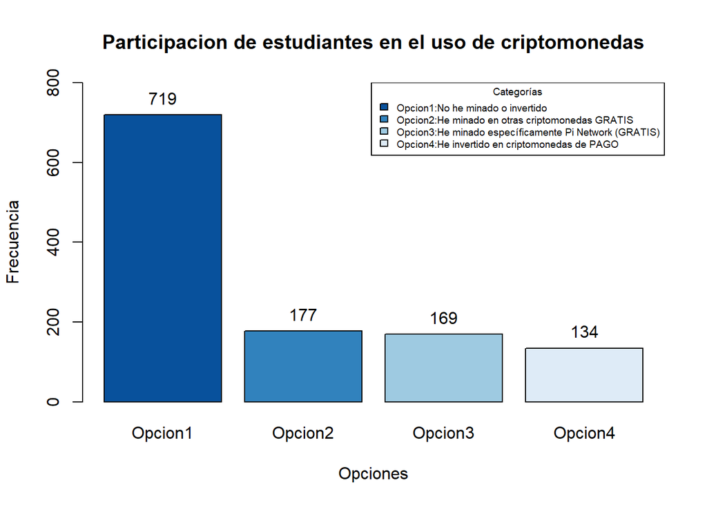

De este gráfico, observamos que la mayoría de encuestados `No ha minado o invertido en criptomonedas`.

**Carrera**

Tenemos 7 categorías.

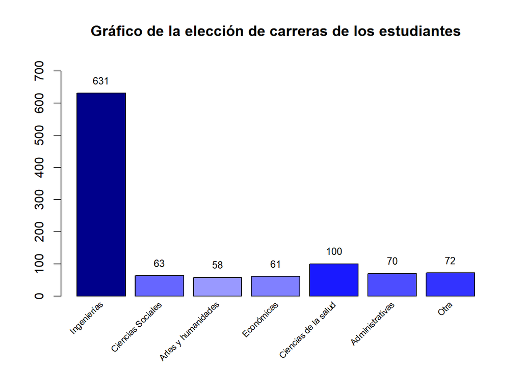

En este gráfico, observamos que la mayoría de encuestados estudian `Ingenierías`.

**Departamento**

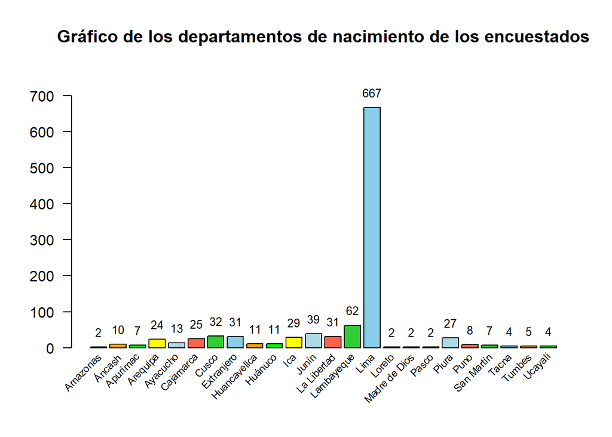

De este gráfico,notamos que la mayoría ha nacido en `Lima`.

**Nivel de educacion financiera**

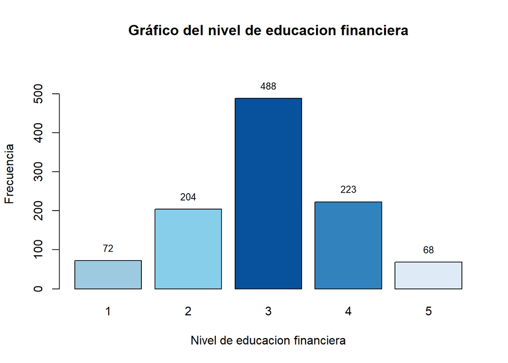

De este gráfico,la mayoría considera que tiene un `nivel de educación financiera promedio(3)`.

**Escala socioeconomica**

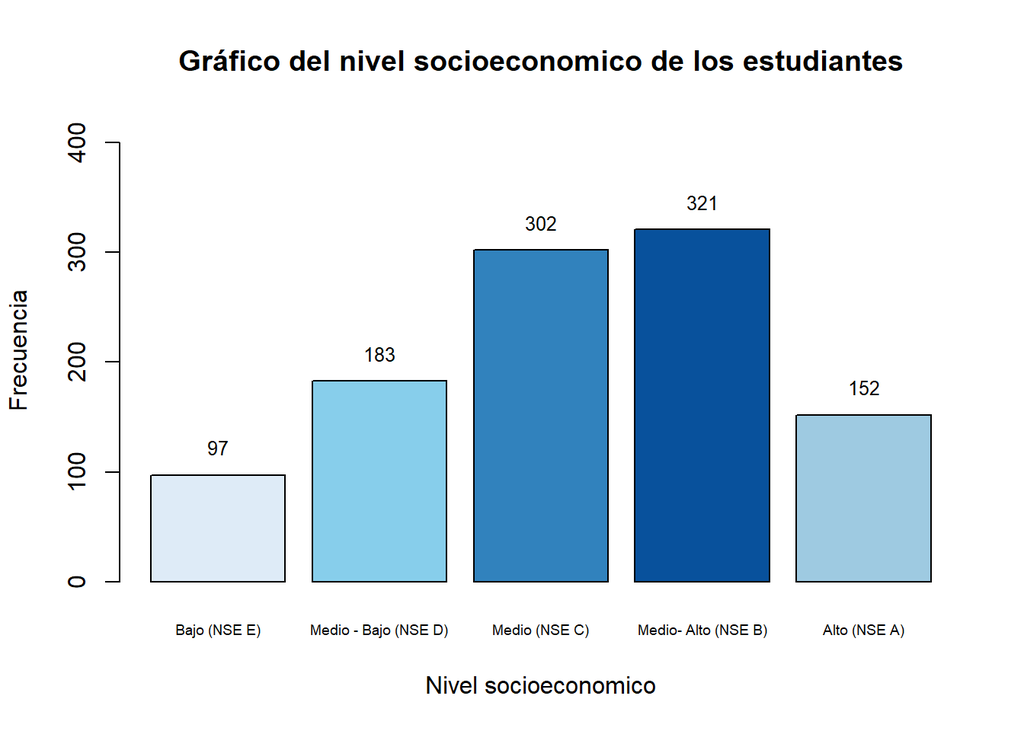

De este gráfico,la mayoría de los estudiantes esta posicionado en el nivel socieconómico `Medio-Alto(NSE B)`.

### 3.1.2 Variables Cuantitativas

**Gasto mensual en efectivo**

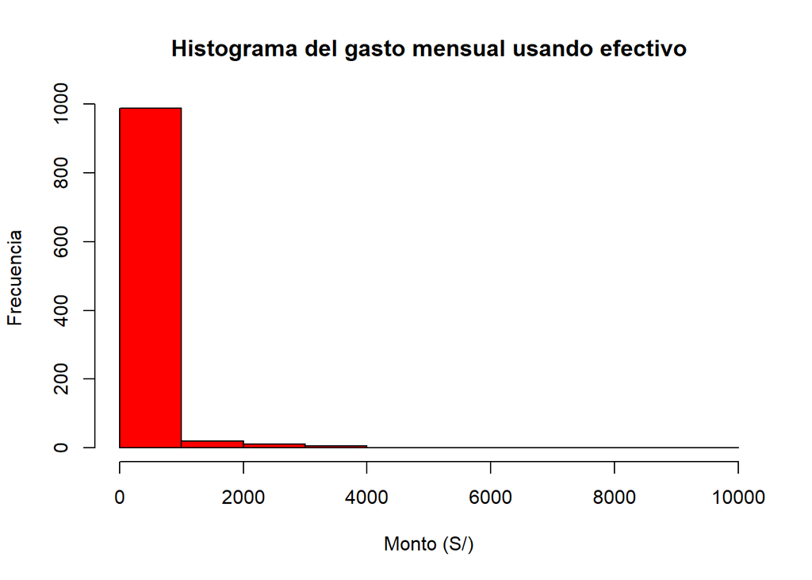

En el gráfico anterior,se observa que debido a los valores atípicos altos este histograma no resulta muy informativo.Se decidió hacer un zoom en el gráfico de tal manera que resulte más informativo.Se escogen valores menores o iguales a 2000 soles.Este gráfico esta evaluando 1006 datos.

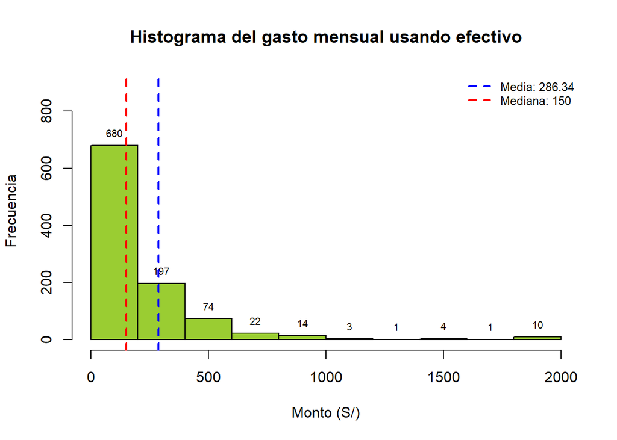

```
   Min. 1st Qu.  Median    Mean 3rd Qu.    Max.    NA's
    0.0    60.0   150.0   286.3   300.0 10000.0      31
```

```
Mediana: 150
```

```
Media: 286.3418
```

```
Maximo: 10000
```

```
Minimo: 0
```

```
Rango: 10000
```

```
Desviación estándar: 566.3087
```

```
Coeficiente de variacion: 1.977737
```

Se observa que, en promedio, el gasto mensual en efectivo de los estudiantes encuestados es de `286.3` soles. Sin embargo, este gasto varía ampliamente, oscilando entre `0 y 10,000 soles`. Además, el `25%` de los estudiantes gasta más de `300` soles al mes en efectivo, mientras que la mitad de ellos supera al menos los `150` soles mensuales. Cabe resaltar que los datos presentan una alta dispersión, reflejada en un coeficiente de variación de `1.98`, lo que indica una considerable variabilidad en los gastos entre los estudiantes.

**Gasto mensual en billeteras virtuales**

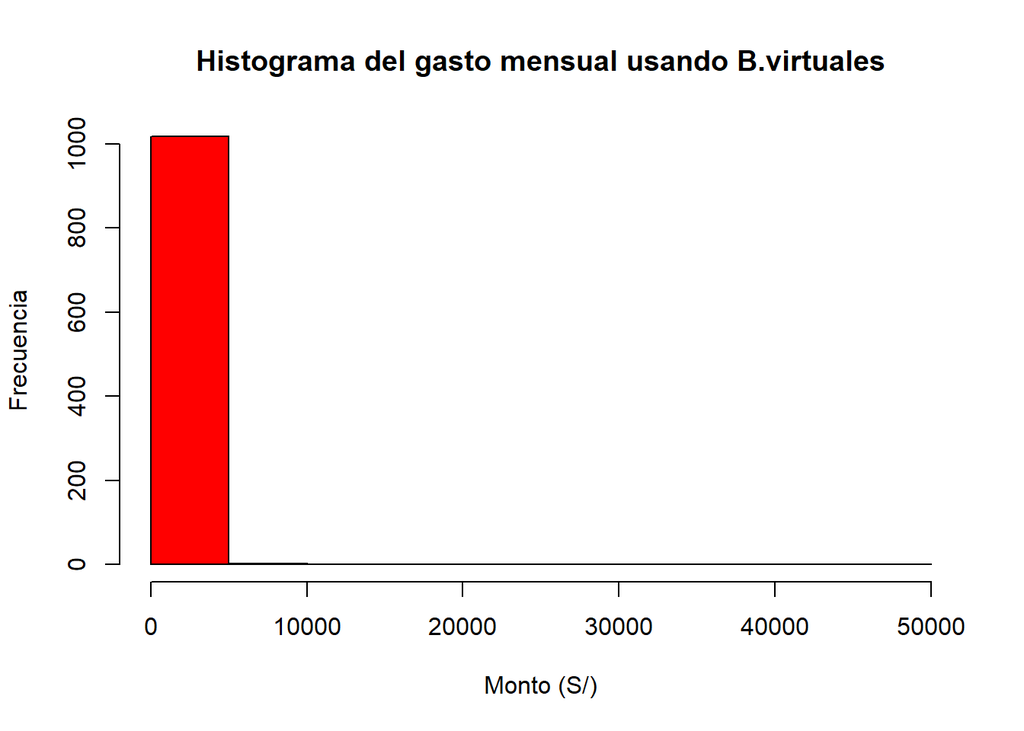

En el gráfico anterior,se observa que debido a los valores atípicos altos este histograma no resulta muy informativo.Se decidió hacer un zoom en el gráfico de tal manera que resulte más informativo.Se escogen valores menores o iguales a 3000 soles.Este gráfico esta evaluando 1005 datos.

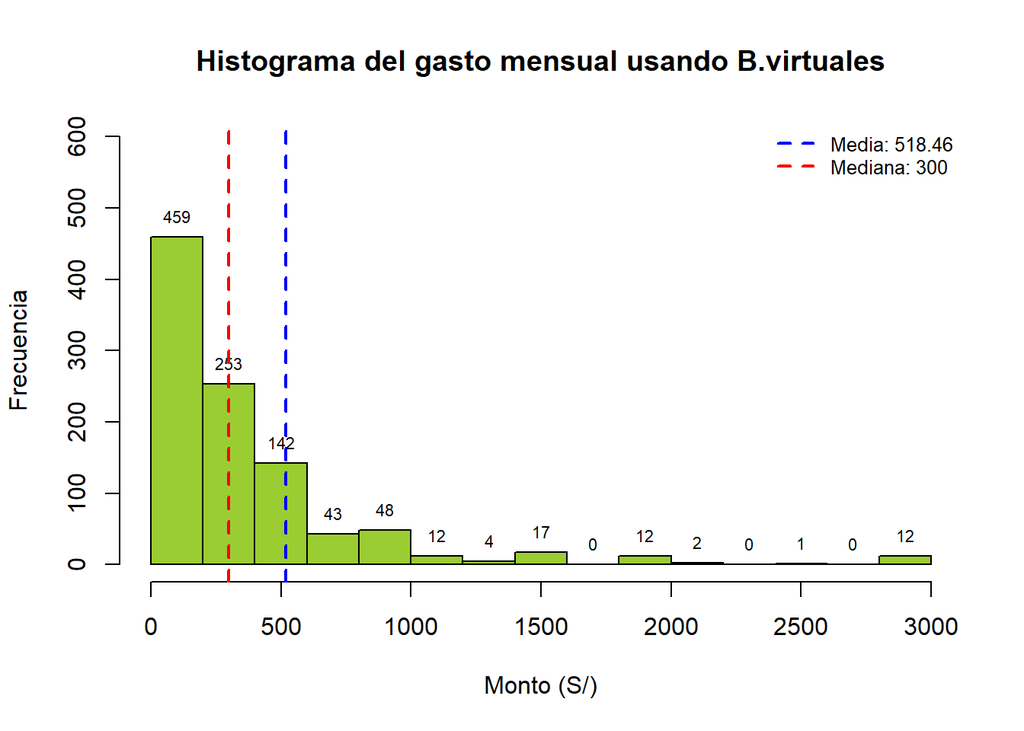

```
   Min. 1st Qu.  Median    Mean 3rd Qu.    Max.    NA's
    0.0   100.0   300.0   518.5   500.0 50000.0      34
```

```
Mediana: 300
```

```
Media: 518.4643
```

```
Maximo: 50000
```

```
Minimo: 0
```

```
Rango: 50000
```

```
Desviación estándar: 1804.734
```

```
Coeficiente de variacion: 3.480922
```

Se observa que, en promedio, el gasto mensual mediante billeteras digitales (como Yape, Plin, entre otras) de los estudiantes encuestados es de `518.46` soles. No obstante, este gasto presenta una amplia variabilidad, con gastos que oscilan entre `0 y 50,000` soles. Además, el `25%` de los estudiantes gasta más de `500` soles mensualmente a través de estas apps, mientras que la mitad al menos supera los `300` soles al mes. Es importante destacar que los datos presentan una alta dispersión, evidenciada por un coeficiente de variación de `3.48`,lo que indica una considerable variabilidad en los gastos entre los estudiantes.

**Frecuencia de minado por dias/semana**

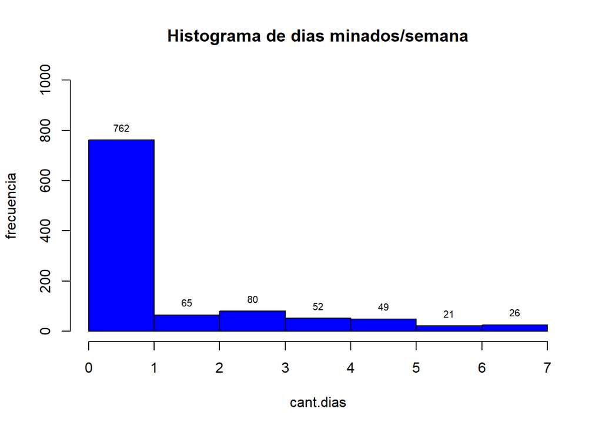

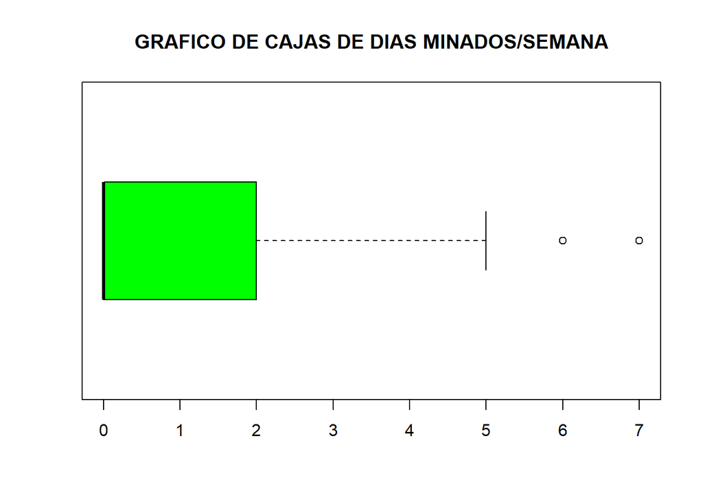

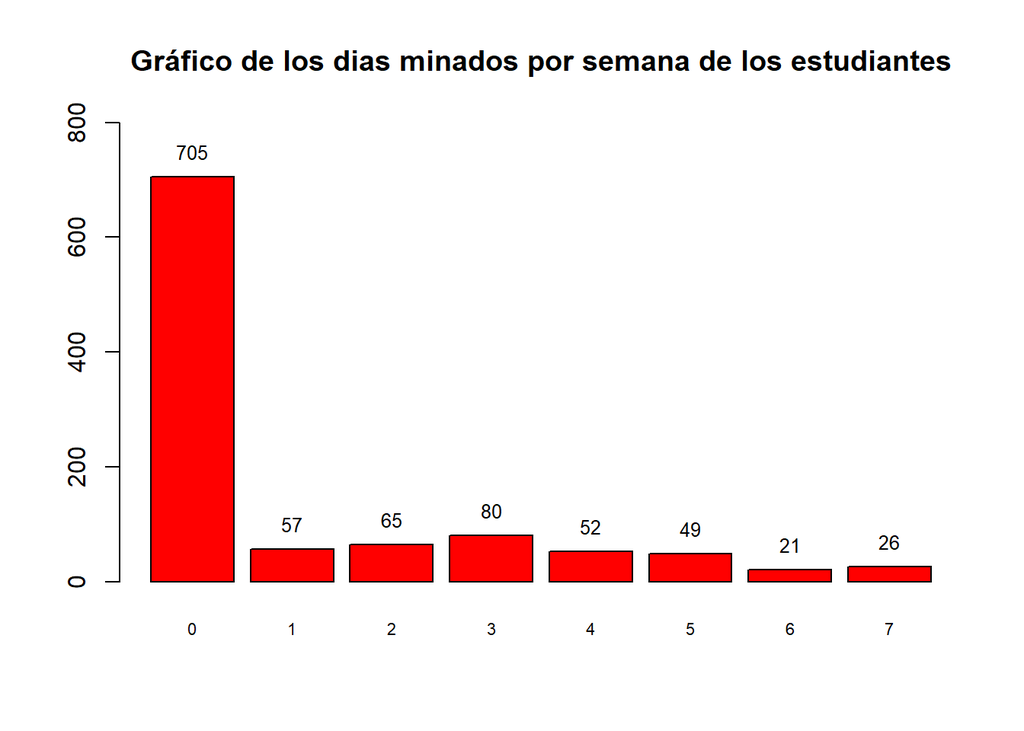

```
   Min. 1st Qu.  Median    Mean 3rd Qu.    Max.
  0.000   0.000   0.000   1.126   2.000   7.000
```

Se observa que en promedio la frecuencia de minado de criptomonedas de los estudiantes encuestados es de 1.13 días por semana.No obstante,este gasto oscila entre el rango de `0 a 7` días minados por semana .Además,el `25%` de los estudiantes minan criptomonedas más de `2` días por semana ,al menos la mitad no mina criptomonedas.Se optó por un `barplot` a pesar de ser una variable cuantitativa solo para observar las frecuencias ya que esta variable tiene pocos valores.

## 3.2 Análisis de interacción

### 3.2.1 Objetivo 1

- Minado de criptomonedas gratis:

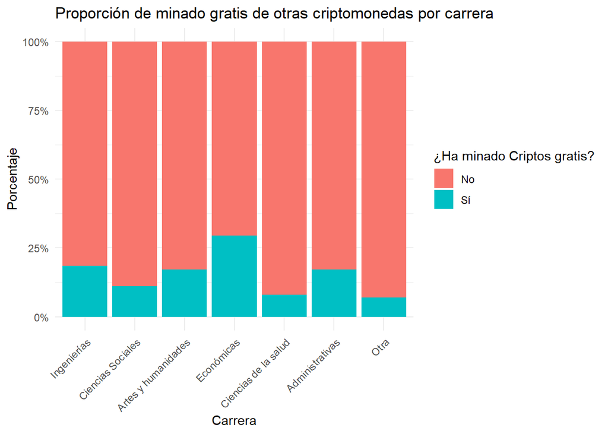

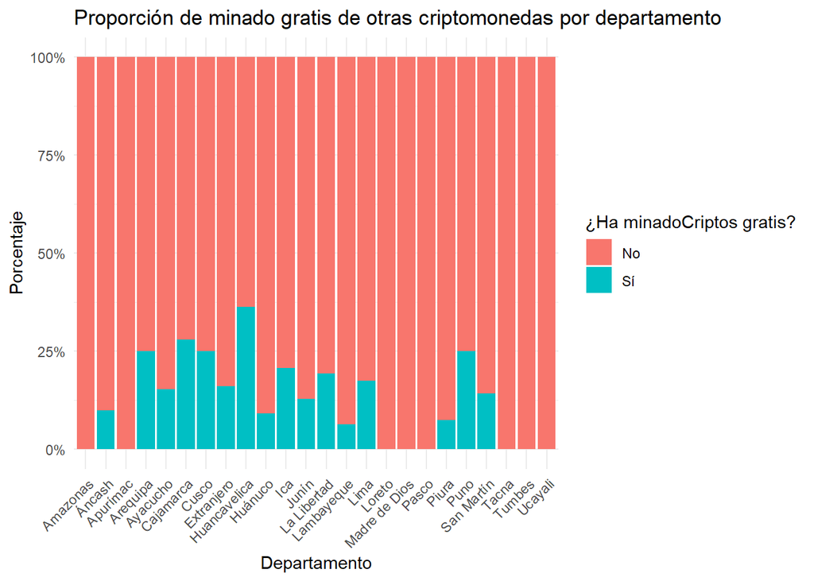

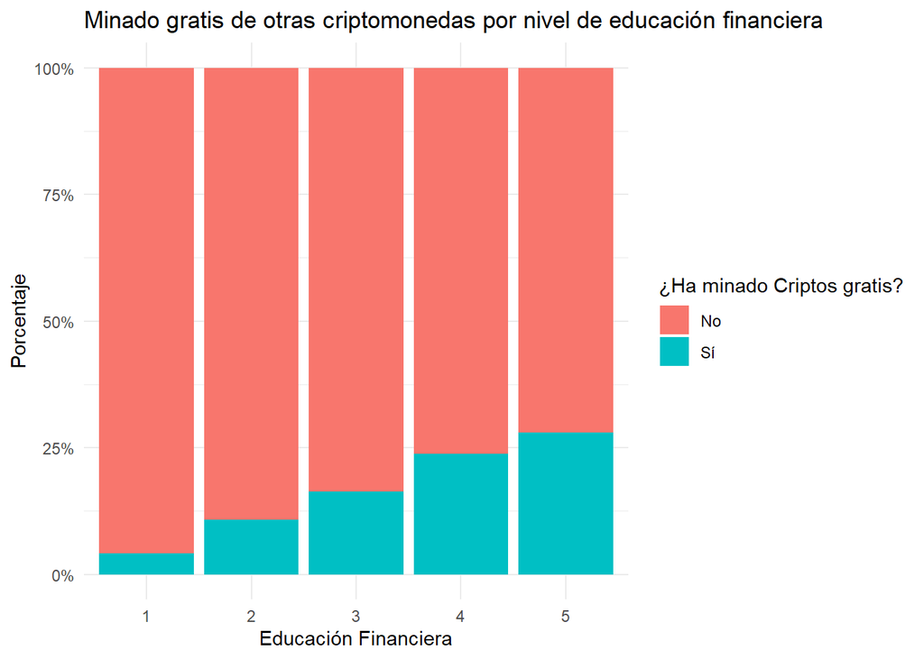

Los gráficos muestran que, en todas las categorías analizadas `(carrera, departamento y educación financiera)`, predomina la proporción de personas que no han realizado minado gratuito de criptomonedas. Sin embargo, también evidencian que la adopción de esta práctica se ve positivamente influenciada por el nivel de conocimiento financiero y la orientación académica, destacándose una mayor participación entre quienes pertenecen al área económica.Además,la mayor incidencia se encuentra en las personas nacidas en el departamento de `Huancavelica`.

- Minado de criptomonedas de pago:

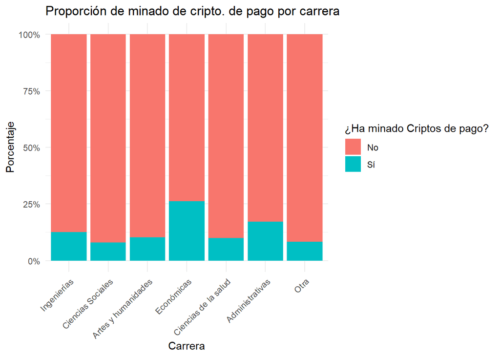

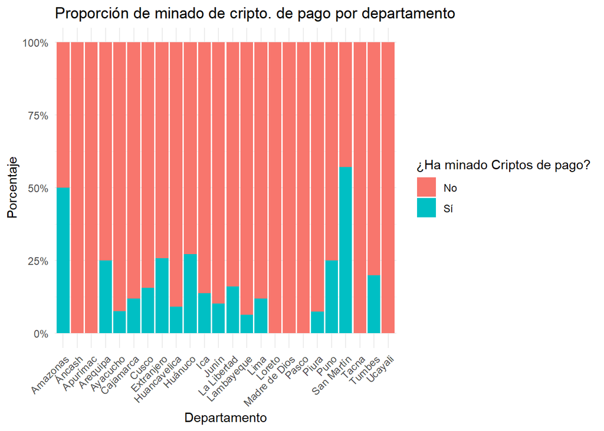

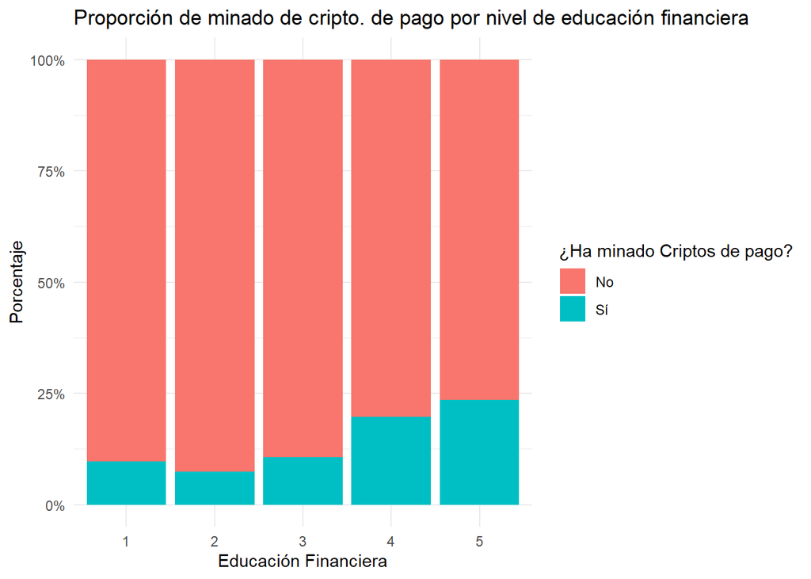

Los gráficos muestran que, en todas las categorías analizadas `(carrera, departamento y educación financiera)`, predomina la proporción de personas que no han realizado minado de criptomonedas de pago.En conjunto, los gráficos indican que la adopción del minado de pago está influenciada positivamente por el nivel de conocimiento financiero y la orientación académica con una mayor participación de quienes pertenecen al área económica.Además,la mayores incidencias se encuentra en las personas nacidas en los departamentos de `Amazonas y San Martín`.

- Minado de PI NETWORK:

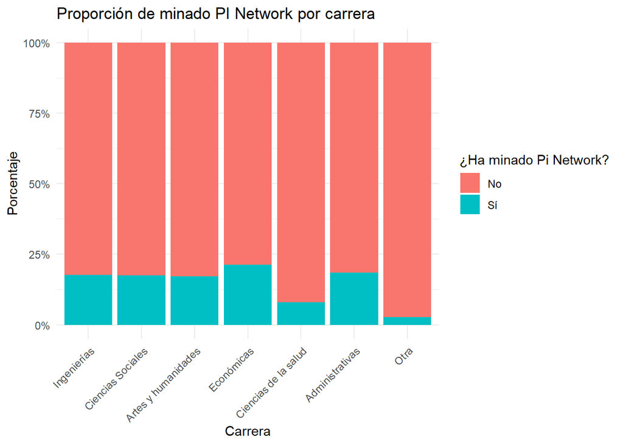

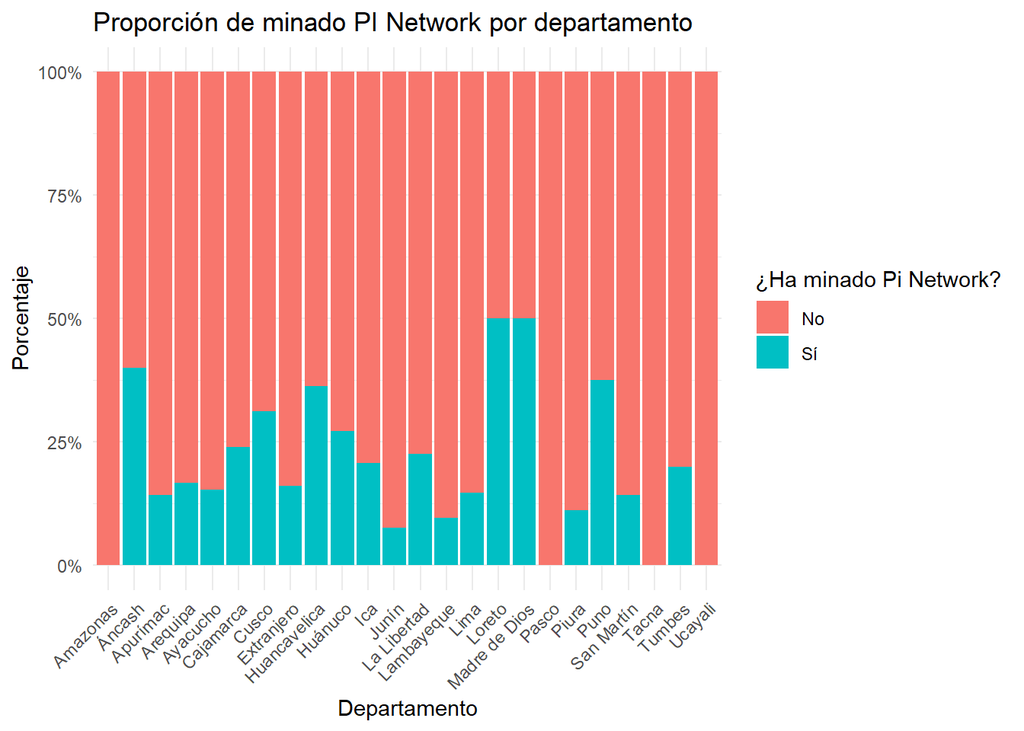

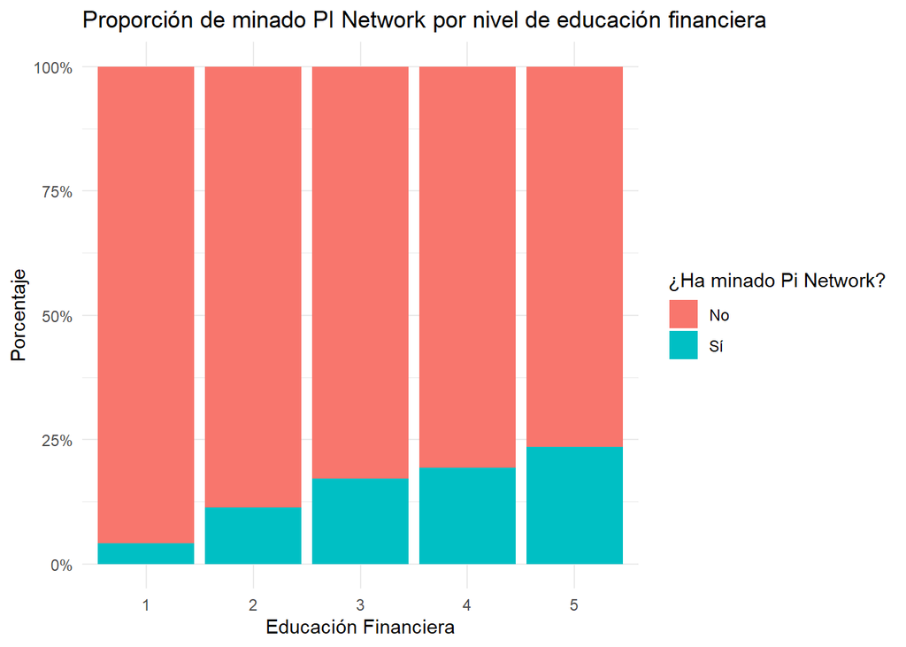

Los gráficos muestran que, en todas las categorías analizadas `(carrera, departamento y educación financiera)`, predomina la proporción de personas que no han realizado minado de la criptomoneda `PI NETWORK`. En conjunto, los gráficos muestran que la adopción del minado de PI Network está positivamente influenciada por el nivel de conocimiento financiero y la formación académica,especialmente en el área económica. Además,la mayores incidencias se encuentra en las personas nacidas en los departamentos de `Loreto y Madre de Dios`. Es decir, a mayor educación financiera y conocimiento, mayor es la tendencia a involucrarse en inversiones digitales como PI Network.

### 3.2.2 Objetivo 2

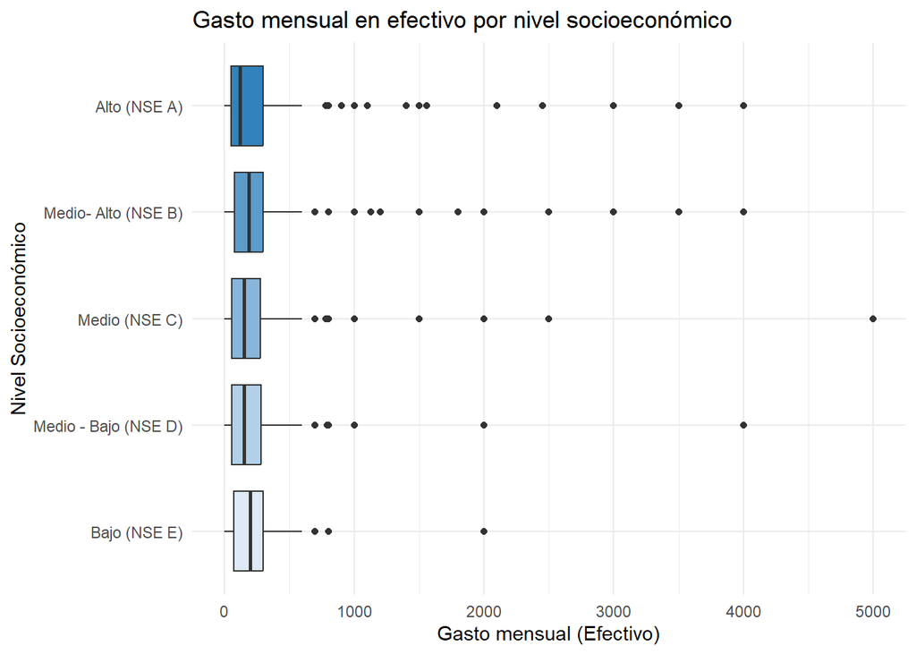

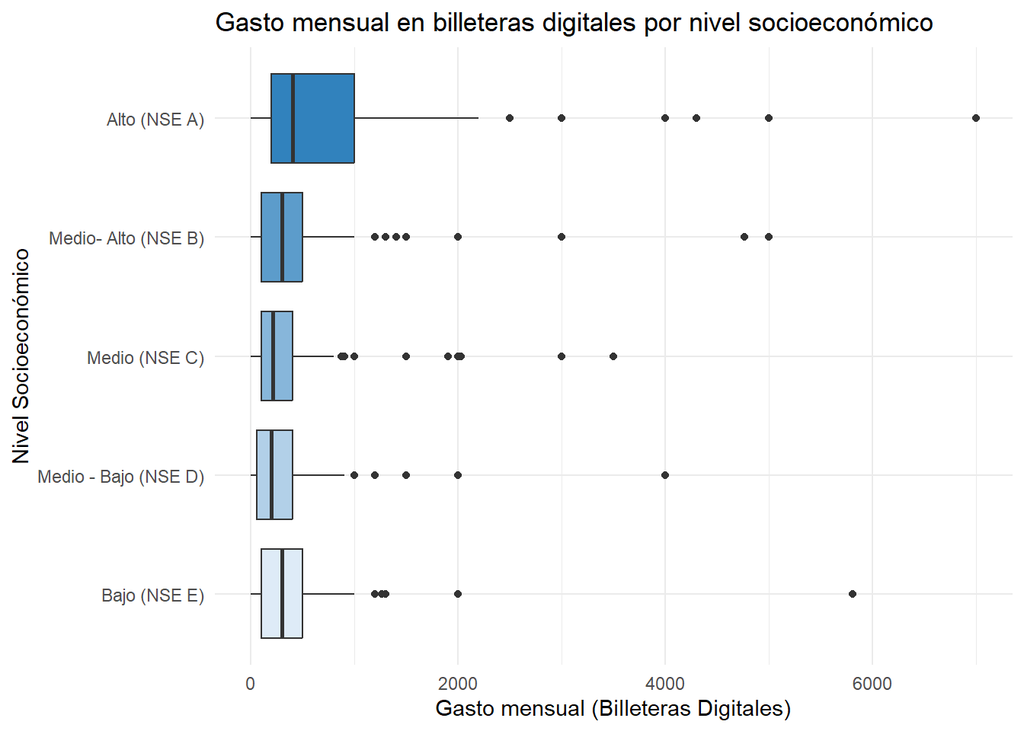

Similar al anterior, un mayor nivel socioeconomico simboliza un mayor ingreso, por lo tanto el gasto mensual tiende a ser mayor, si bien los niveles tienen a tener gastos en un rango hasta 500 soles, vemos una distancia clara con las personas de Alto nivel, los cuales hacen uso mayor de su billetera digital, sobrepasando los 1000 soles y un rango mayor a 500 de manera unanime.

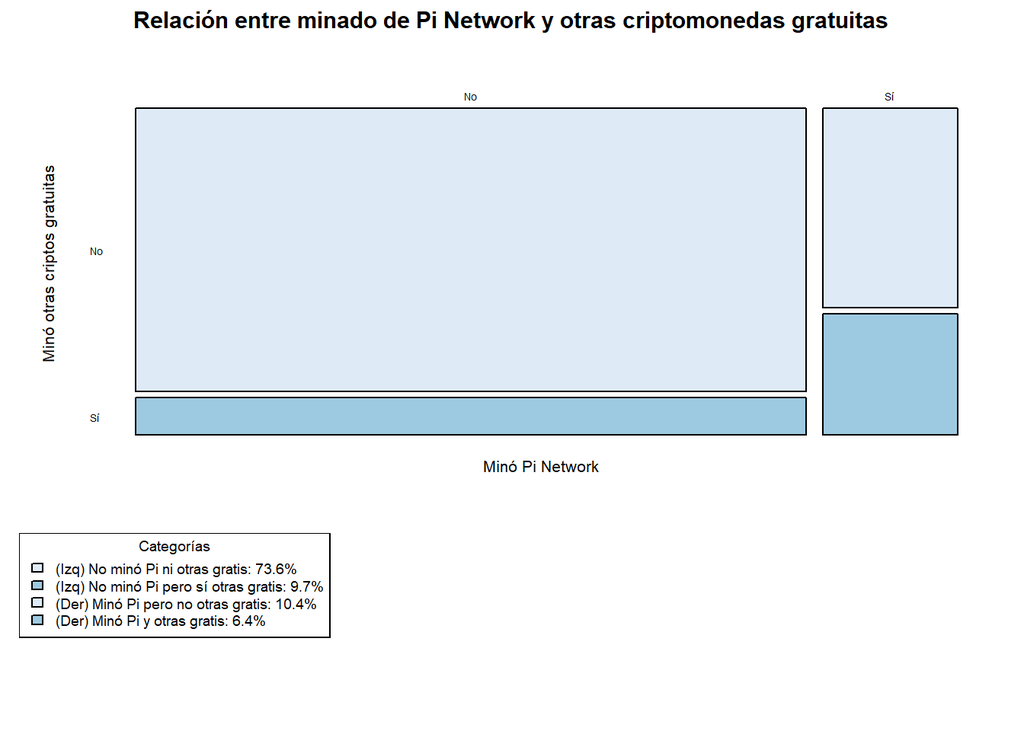

Se observa la relación entre los estudiantes que han minado Pi Network y aquellos que han minado otras criptomonedas gratuitas. Del total de 1055 personas analizadas, 67 han minado tanto Pi Network como otras criptomonedas gratuitas, lo que representa el 6.4 % del total. Esto sugiere una posible asociación entre ambas conductas: los estudiantes que minan Pi Network también tienden a explorar otras opciones gratuitas de criptominería.

# 4 Conclusiones:

El análisis estadístico realizado en el periodo 2025-1 en UTEC sobre el conocimiento, uso y percepción de la criptomoneda Pi Network entre estudiantes universitarios revela un panorama de baja adopción general, pero con nichos específicos de interés y oportunidades de mejora educativa. Los resultados evidencian tendencias importantes respecto a los perfiles de los estudiantes, sus hábitos financieros y la relación entre educación financiera y adopción tecnológica.

En resumen, se observa que la mayoría de estudiantes no ha tenido experiencia con criptomonedas, aunque una tercera parte ha realizado actividades de minería digital. Predominan los estudiantes de ingeniería, procedentes de Lima y con un nivel de educación financiera promedio (nivel 3). Aquellos con mayor educación financiera tienden a explorar más activamente la minería de criptomonedas, especialmente a través de opciones gratuitas como Pi Network, que suele estar asociada con el interés por otras criptomonedas similares. Además, los estudiantes muestran un mayor uso de billeteras digitales frente al efectivo, el gasto mensual promedio en billeteras digitales es de 518.46 soles (mediana: 300 soles), superando al gasto en efectivo, que promedia 286.34 soles (mediana: 150 soles), aunque existe una amplia variabilidad en los montos gastados. Todo esto resalta la importancia de reforzar la educación financiera y tecnológica dentro del entorno universitario, para incentivar una adopción informada y segura de nuevas herramientas financieras digitales.